# CCBS Relationship Study Output.sav

[output not shown]

Log  
Log - Log - October 6, 2020

FREQUENCIES VARIABLES=Primary_Motivation Time_Thinking Most_Important_1 Most_Important_2  
Most_Important_3 Where_Purchased Expectations_Met Live_With Live_With_Time Where_Is_Dog_Now  
Consider_Getting_Another_Dog  
/PIECHART PERCENT  
/ORDER=ANALYSIS.

Frequencies  
Frequencies - Statistics - October 6, 2020

StatisticsStatistics, table, 1 levels of column headers and 2 levels of row headers, table with 13 columns and 4 rows

|  |  | Primary_Motivation | Time_Thinking | Most_Important_1 | Most_Important_2 | Most_Important_3 | Where_Purchased | Expectations_Met | Live_With | Live_With_Time | Where_Is_Dog_Now | Consider_Getting_Another_Dog |
| --- | --- | --- | --- | --- | --- | --- | --- | --- | --- | --- | --- | --- |
| N | Valid | 1704 | 1704 | 1704 | 1704 | 1704 | 1704 | 1704 | 1704 | 196 | 196 | 1033 |
|  | Missing | 0 | 0 | 0 | 0 | 0 | 0 | 0 | 0 | 1508 | 1508 | 671 |

Frequency Table  
Frequency Table - Primary_Motivation - October 6, 2020

Primary_MotivationPrimary_Motivation, table, 1 levels of column headers and 2 levels of row headers, table with 6 columns and 14 rows

|  |  | Frequency | Percent | Valid Percent | Cumulative Percent |
| --- | --- | --- | --- | --- | --- |
| Valid | Companionship and affection | 939 | 55.1 | 55.1 | 55.1 |
|  | Social interaction | 24 | 1.4 | 1.4 | 56.5 |
|  | Exercise and adventure partner | 87 | 5.1 | 5.1 | 61.6 |
|  | Protection | 12 | .7 | .7 | 62.3 |
|  | Working or sporting | 121 | 7.1 | 7.1 | 69.4 |
|  | Someone else in the home wanted a dog | 77 | 4.5 | 4.5 | 73.9 |
|  | Companion for another dog or pet | 258 | 15.1 | 15.1 | 89.1 |
|  | Dog needed a home | 122 | 7.2 | 7.2 | 96.2 |
|  | Assistance or therapy dog | 12 | .7 | .7 | 96.9 |
|  | Foster fail | 13 | .8 | .8 | 97.7 |
|  | Other | 39 | 2.3 | 2.3 | 100.0 |
|  | Total | 1704 | 100.0 | 100.0 |  |

Frequency Table  
Frequency Table - Time_Thinking - October 6, 2020

Time_ThinkingTime_Thinking, table, 1 levels of column headers and 2 levels of row headers, table with 6 columns and 7 rows

|  |  | Frequency | Percent | Valid Percent | Cumulative Percent |
| --- | --- | --- | --- | --- | --- |
| Valid | Less than 1 week | 213 | 12.5 | 12.5 | 12.5 |
|  | 1 week to 6 months | 835 | 49.0 | 49.0 | 61.5 |
|  | 6+ months to 6 years | 587 | 34.4 | 34.4 | 96.0 |
|  | 6+ years | 69 | 4.0 | 4.0 | 100.0 |
|  | Total | 1704 | 100.0 | 100.0 |  |

Frequency Table  
Frequency Table - Most_Important_1 - October 6, 2020

Most_Important_1Most_Important_1, table, 1 levels of column headers and 2 levels of row headers, table with 6 columns and 10 rows

|  |  | Frequency | Percent | Valid Percent | Cumulative Percent |
| --- | --- | --- | --- | --- | --- |
| Valid | Appearance | 117 | 6.9 | 6.9 | 6.9 |
|  | Breed | 497 | 29.2 | 29.2 | 36.0 |
|  | Size | 111 | 6.5 | 6.5 | 42.5 |
|  | Age | 71 | 4.2 | 4.2 | 46.7 |
|  | Individual personality or behavior | 627 | 36.8 | 36.8 | 83.5 |
|  | Trainability | 43 | 2.5 | 2.5 | 86.0 |
|  | Compatibility with other pets | 238 | 14.0 | 14.0 | 100.0 |
|  | Total | 1704 | 100.0 | 100.0 |  |

Frequency Table  
Frequency Table - Most_Important_2 - October 6, 2020

Most_Important_2Most_Important_2, table, 1 levels of column headers and 2 levels of row headers, table with 6 columns and 10 rows

|  |  | Frequency | Percent | Valid Percent | Cumulative Percent |
| --- | --- | --- | --- | --- | --- |
| Valid | Appearance | 169 | 9.9 | 9.9 | 9.9 |
|  | Breed | 208 | 12.2 | 12.2 | 22.1 |
|  | Size | 229 | 13.4 | 13.4 | 35.6 |
|  | Age | 214 | 12.6 | 12.6 | 48.1 |
|  | Individual personality or behavior | 467 | 27.4 | 27.4 | 75.5 |
|  | Trainability | 176 | 10.3 | 10.3 | 85.9 |
|  | Compatability with other pets | 241 | 14.1 | 14.1 | 100.0 |
|  | Total | 1704 | 100.0 | 100.0 |  |

Frequency Table  
Frequency Table - Most_Important_3 - October 6, 2020

Most_Important_3Most_Important_3, table, 1 levels of column headers and 2 levels of row headers, table with 6 columns and 10 rows

|  |  | Frequency | Percent | Valid Percent | Cumulative Percent |
| --- | --- | --- | --- | --- | --- |
| Valid | Appearance | 243 | 14.3 | 14.3 | 14.3 |
|  | Breed | 163 | 9.6 | 9.6 | 23.8 |
|  | Size | 293 | 17.2 | 17.2 | 41.0 |
|  | Age | 310 | 18.2 | 18.2 | 59.2 |
|  | Individual personality or behavior | 250 | 14.7 | 14.7 | 73.9 |
|  | Trainability | 268 | 15.7 | 15.7 | 89.6 |
|  | Compatibility with other pets | 177 | 10.4 | 10.4 | 100.0 |
|  | Total | 1704 | 100.0 | 100.0 |  |

Frequency Table  
Frequency Table - Where_Purchased - October 6, 2020

Where_PurchasedWhere_Purchased, table, 1 levels of column headers and 2 levels of row headers, table with 6 columns and 10 rows

|  |  | Frequency | Percent | Valid Percent | Cumulative Percent |
| --- | --- | --- | --- | --- | --- |
| Valid | Breeder | 537 | 31.5 | 31.5 | 31.5 |
|  | Online | 57 | 3.3 | 3.3 | 34.9 |
|  | Locak pet shop | 18 | 1.1 | 1.1 | 35.9 |
|  | Shelter or rescue | 881 | 51.7 | 51.7 | 87.6 |
|  | Family member or friend | 141 | 8.3 | 8.3 | 95.9 |
|  | Found roaming | 56 | 3.3 | 3.3 | 99.2 |
|  | Another country or island | 14 | .8 | .8 | 100.0 |
|  | Total | 1704 | 100.0 | 100.0 |  |

Frequency Table  
Frequency Table - Expectations_Met - October 6, 2020

Expectations_MetExpectations_Met, table, 1 levels of column headers and 2 levels of row headers, table with 6 columns and 7 rows

|  |  | Frequency | Percent | Valid Percent | Cumulative Percent |
| --- | --- | --- | --- | --- | --- |
| Valid | Yes | 1421 | 83.4 | 83.4 | 83.4 |
|  | Partially, I grew to love the dog over time | 167 | 9.8 | 9.8 | 93.2 |
|  | Partially I accepted the dog and made it work | 109 | 6.4 | 6.4 | 99.6 |
|  | No, the dog was not a good match | 7 | .4 | .4 | 100.0 |
|  | Total | 1704 | 100.0 | 100.0 |  |

Frequency Table  
Frequency Table - Live_With - October 6, 2020

Live_WithLive_With, table, 1 levels of column headers and 2 levels of row headers, table with 6 columns and 5 rows

|  |  | Frequency | Percent | Valid Percent | Cumulative Percent |
| --- | --- | --- | --- | --- | --- |
| Valid | No | 196 | 11.5 | 11.5 | 11.5 |
|  | Yes | 1508 | 88.5 | 88.5 | 100.0 |
|  | Total | 1704 | 100.0 | 100.0 |  |

Frequency Table  
Frequency Table - Live_With_Time - October 6, 2020

Live_With_TimeLive_With_Time, table, 1 levels of column headers and 2 levels of row headers, table with 6 columns and 9 rows

|  |  | Frequency | Percent | Valid Percent | Cumulative Percent |
| --- | --- | --- | --- | --- | --- |
| Valid | LT 1 week | 1 | .1 | .5 | .5 |
|  | 1 week to 6 months | 4 | .2 | 2.0 | 2.6 |
|  | 6+ months to 6 years | 36 | 2.1 | 18.4 | 20.9 |
|  | 6+ years | 155 | 9.1 | 79.1 | 100.0 |
|  | Total | 196 | 11.5 | 100.0 |  |
| Missing | System | 1508 | 88.5 |  |  |
| Total |  | 1704 | 100.0 |  |  |

Frequency Table  
Frequency Table - Where_Is_Dog_Now - October 6, 2020

Where_Is_Dog_NowWhere_Is_Dog_Now, table, 1 levels of column headers and 2 levels of row headers, table with 6 columns and 10 rows

|  |  | Frequency | Percent | Valid Percent | Cumulative Percent |
| --- | --- | --- | --- | --- | --- |
| Valid | Rehomed | 12 | .7 | 6.1 | 6.1 |
|  | Surrendered to shelter or rescue | 1 | .1 | .5 | 6.6 |
|  | Euthanized | 34 | 2.0 | 17.3 | 24.0 |
|  | Ran away | 1 | .1 | .5 | 24.5 |
|  | Passed | 148 | 8.7 | 75.5 | 100.0 |
|  | Total | 196 | 11.5 | 100.0 |  |
| Missing | System | 1508 | 88.5 |  |  |
| Total |  | 1704 | 100.0 |  |  |

Frequency Table  
Frequency Table - Consider_Getting_Another_Dog - October 6, 2020

Consider_Getting_Another_DogConsider_Getting_Another_Dog, table, 1 levels of column headers and 2 levels of row headers, table with 6 columns and 7 rows

|  |  | Frequency | Percent | Valid Percent | Cumulative Percent |
| --- | --- | --- | --- | --- | --- |
| Valid | No | 69 | 4.0 | 6.7 | 6.7 |
|  | Yes | 964 | 56.6 | 93.3 | 100.0 |
|  | Total | 1033 | 60.6 | 100.0 |  |
| Missing | System | 671 | 39.4 |  |  |
| Total |  | 1704 | 100.0 |  |  |

Pie Chart  
Pie Chart - Primary_Motivation - October 6, 2020

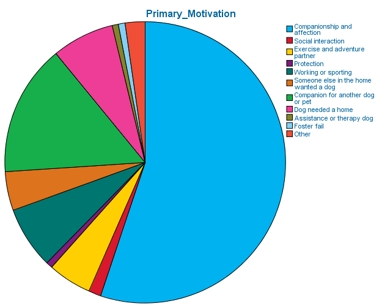

Pie Chart  
Pie Chart - Time_Thinking - October 6, 2020

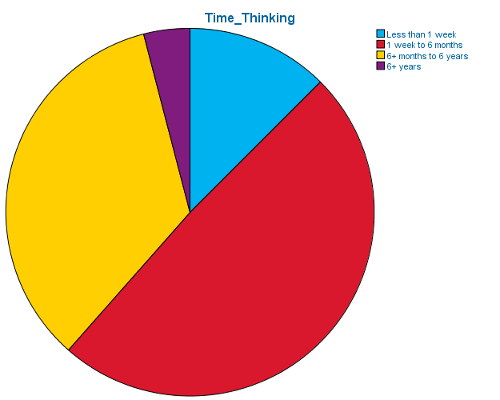

Pie Chart  
Pie Chart - Most_Important_1 - October 6, 2020

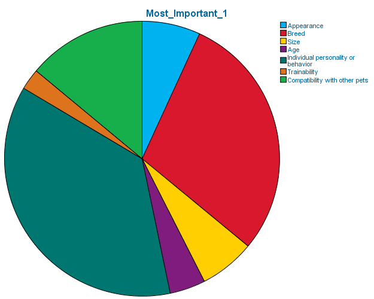

Pie Chart  
Pie Chart - Most_Important_2 - October 6, 2020

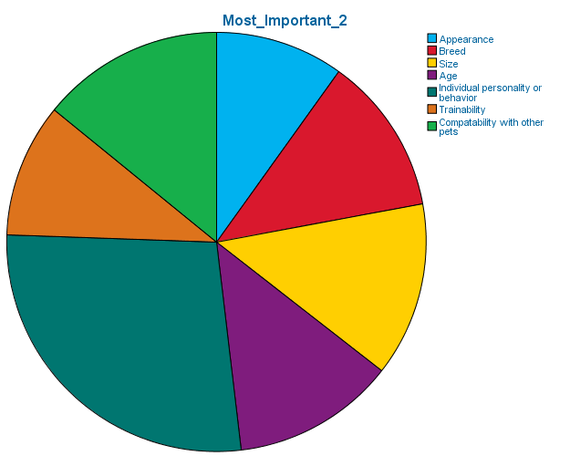

Pie Chart  
Pie Chart - Most_Important_3 - October 6, 2020

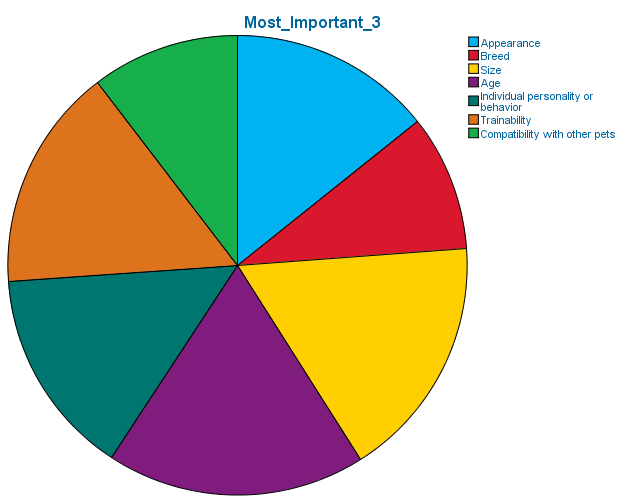

Pie Chart  
Pie Chart - Where_Purchased - October 6, 2020

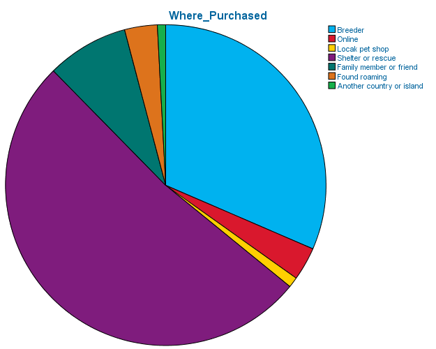

Pie Chart  
Pie Chart - Expectations_Met - October 6, 2020

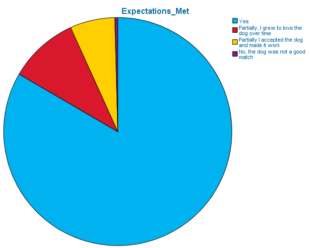

Pie Chart  
Pie Chart - Live_With - October 6, 2020

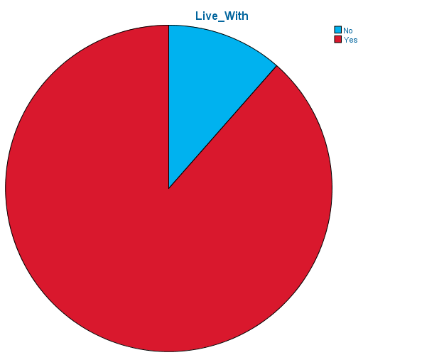

Pie Chart  
Pie Chart - Live_With_Time - October 6, 2020

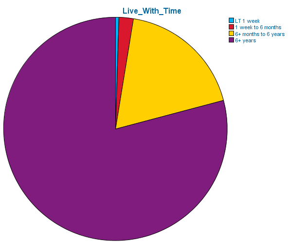

Pie Chart  
Pie Chart - Where_Is_Dog_Now - October 6, 2020

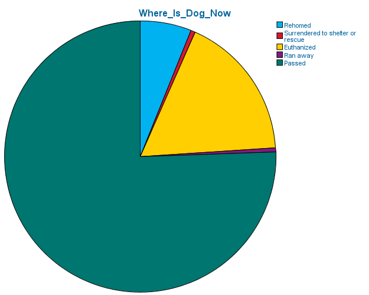

Pie Chart  
Pie Chart - Consider_Getting_Another_Dog - October 6, 2020

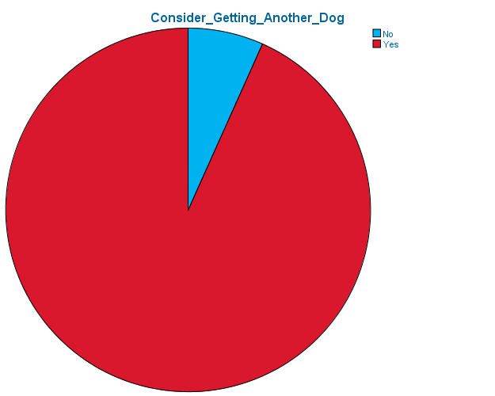

Log  
Log - Log - October 6, 2020

NOMREG Expectations_Met (BASE=LAST ORDER=ASCENDING) BY Time_Thinking Primary_Motivation  
Most_Important_1 Most_Important_2 Most_Important_3  
/CRITERIA CIN(95) DELTA(0) MXITER(100) MXSTEP(5) CHKSEP(20) LCONVERGE(0) PCONVERGE(0.000001)  
SINGULAR(0.00000001)  
/MODEL  
/STEPWISE=PIN(.05) POUT(0.1) MINEFFECT(0) RULE(SINGLE) ENTRYMETHOD(LR) REMOVALMETHOD(LR)  
/INTERCEPT=INCLUDE  
/PRINT=PARAMETER SUMMARY LRT CPS STEP MFI.

Nominal Regression  
Nominal Regression - Warnings - October 6, 2020

WarningsWarnings, table, 0 levels of column headers and 0 levels of row headers, table with 1 columns and 3 rows

| Unexpected singularities in the Hessian matrix are encountered. This indicates that either some predictor variables should be excluded or some categories should be merged. |
| --- |
| The NOMREG procedure continues despite the above warning(s). Subsequent results shown are based on the last iteration. Validity of the model fit is uncertain. |

Nominal Regression  
Nominal Regression - Case Processing Summary - October 6, 2020

Case Processing SummaryCase Processing Summary, table, 1 levels of column headers and 2 levels of row headers, table with 4 columns and 47 rows

|  |  | N | Marginal Percentage |
| --- | --- | --- | --- |
| Expectations_Met | Yes | 1421 | 83.4% |
|  | Partially, I grew to love the dog over time | 167 | 9.8% |
|  | Partially I accepted the dog and made it work | 109 | 6.4% |
|  | No, the dog was not a good match | 7 | 0.4% |
| Time_Thinking | Less than 1 week | 213 | 12.5% |
|  | 1 week to 6 months | 835 | 49.0% |
|  | 6+ months to 6 years | 587 | 34.4% |
|  | 6+ years | 69 | 4.0% |
| Primary_Motivation | Companionship and affection | 939 | 55.1% |
|  | Social interaction | 24 | 1.4% |
|  | Exercise and adventure partner | 87 | 5.1% |
|  | Protection | 12 | 0.7% |
|  | Working or sporting | 121 | 7.1% |
|  | Someone else in the home wanted a dog | 77 | 4.5% |
|  | Companion for another dog or pet | 258 | 15.1% |
|  | Dog needed a home | 122 | 7.2% |
|  | Assistance or therapy dog | 12 | 0.7% |
|  | Foster fail | 13 | 0.8% |
|  | Other | 39 | 2.3% |
| Most_Important_1 | Appearance | 117 | 6.9% |
|  | Breed | 497 | 29.2% |
|  | Size | 111 | 6.5% |
|  | Age | 71 | 4.2% |
|  | Individual personality or behavior | 627 | 36.8% |
|  | Trainability | 43 | 2.5% |
|  | Compatibility with other pets | 238 | 14.0% |
| Most_Important_2 | Appearance | 169 | 9.9% |
|  | Breed | 208 | 12.2% |
|  | Size | 229 | 13.4% |
|  | Age | 214 | 12.6% |
|  | Individual personality or behavior | 467 | 27.4% |
|  | Trainability | 176 | 10.3% |
|  | Compatability with other pets | 241 | 14.1% |
| Most_Important_3 | Appearance | 243 | 14.3% |
|  | Breed | 163 | 9.6% |
|  | Size | 293 | 17.2% |
|  | Age | 310 | 18.2% |
|  | Individual personality or behavior | 250 | 14.7% |
|  | Trainability | 268 | 15.7% |
|  | Compatibility with other pets | 177 | 10.4% |
| Valid |  | 1704 | 100.0% |
| Missing |  | 0 |  |
| Total |  | 1704 |  |
| Subpopulation |  | 848<sup>a</sup> |  |

a. The dependent variable has only one value observed in 711 (83.8%) subpopulations.

Nominal Regression  
Nominal Regression - Model Fitting Information - October 6, 2020

Model Fitting InformationModel Fitting Information, table, 2 levels of column headers and 1 levels of row headers, table with 5 columns and 5 rows

| Model | Model Fitting Criteria | Likelihood Ratio Tests |  |  |
| --- | --- | --- | --- | --- |
|  | -2 Log Likelihood | Chi-Square | df | Sig. |
| Intercept Only | 1532.181 |  |  |  |
| Final | 1390.762 | 141.418 | 93 | .001 |

Nominal Regression  
Nominal Regression - Pseudo R-Square - October 6, 2020

Pseudo R-SquarePseudo R-Square, table, 0 levels of column headers and 1 levels of row headers, table with 2 columns and 4 rows

| Cox and Snell | .080 |
| --- | --- |
| Nagelkerke | .116 |
| McFadden | .072 |

Nominal Regression  
Nominal Regression - Likelihood Ratio Tests - October 6, 2020

Likelihood Ratio TestsLikelihood Ratio Tests, table, 2 levels of column headers and 1 levels of row headers, table with 5 columns and 11 rows

| Effect | Model Fitting Criteria | Likelihood Ratio Tests |  |  |
| --- | --- | --- | --- | --- |
|  | -2 Log Likelihood of Reduced Model | Chi-Square | df | Sig. |
| Intercept | 1390.762<sup>a</sup> | .000 | 0 | . |
| Time_Thinking | 1404.541 | 13.779 | 9 | .130 |
| Primary_Motivation | 1451.987 | 61.225 | 30 | .001 |
| Most_Important_1 | 1425.777 | 35.014 | 18 | .009 |
| Most_Important_2 | 1407.883 | 17.121 | 18 | .515 |
| Most_Important_3 | 1414.417 | 23.655 | 18 | .167 |

The chi-square statistic is the difference in -2 log-likelihoods between the final model and a reduced model. The reduced model is formed by omitting an effect from the final model. The null hypothesis is that all parameters of that effect are 0.  
a. This reduced model is equivalent to the final model because omitting the effect does not increase the degrees of freedom.

Nominal Regression  
Nominal Regression - Parameter Estimates - October 6, 2020

Parameter EstimatesParameter Estimates, table, 2 levels of column headers and 2 levels of row headers, table with 10 columns and 117 rows

| Expectations_Met<sup>a</sup> |  | B | Std. Error | Wald | df | Sig. | Exp(B) | 95% Confidence Interval for Exp(B) |  |
| --- | --- | --- | --- | --- | --- | --- | --- | --- | --- |
|  |  |  |  |  |  |  |  | Lower Bound | Upper Bound |
| Yes | Intercept | 30.539 | 1571.823 | .000 | 1 | .984 |  |  |  |
|  | [Time_Thinking=1] | -.389 | 1182.008 | .000 | 1 | 1.000 | .678 | .000 | .<sup>b</sup> |
|  | [Time_Thinking=2] | -14.389 | .981 | 215.256 | 1 | .000 | 5.634E-7 | 8.242E-8 | 3.852E-6 |
|  | [Time_Thinking=3] | -14.268 | .420 | 1153.027 | 1 | .000 | 6.359E-7 | 2.791E-7 | 1.449E-6 |
|  | [Time_Thinking=4] | 0<sup>c</sup> | . | . | 0 | . | . | . | . |
|  | [Primary_Motivation=1] | -14.602 | 1571.821 | .000 | 1 | .993 | 4.555E-7 | .000 | .<sup>b</sup> |
|  | [Primary_Motivation=2] | -.452 | 5263.992 | .000 | 1 | 1.000 | .636 | .000 | .<sup>b</sup> |
|  | [Primary_Motivation=3] | -.485 | 2635.126 | .000 | 1 | 1.000 | .616 | .000 | .<sup>b</sup> |
|  | [Primary_Motivation=4] | -.175 | 1.248 | .020 | 1 | .888 | .839 | .073 | 9.691 |
|  | [Primary_Motivation=5] | -.443 | 2552.534 | .000 | 1 | 1.000 | .642 | .000 | .<sup>b</sup> |
|  | [Primary_Motivation=6] | .243 | 3752.083 | .000 | 1 | 1.000 | 1.274 | .000 | .<sup>b</sup> |
|  | [Primary_Motivation=7] | -14.938 | 1571.821 | .000 | 1 | .992 | 3.253E-7 | .000 | .<sup>b</sup> |
|  | [Primary_Motivation=8] | -.824 | .691 | 1.422 | 1 | .233 | .439 | .113 | 1.700 |
|  | [Primary_Motivation=9] | -.314 | 1.027 | .093 | 1 | .760 | .731 | .098 | 5.467 |
|  | [Primary_Motivation=10] | .318 | 8622.911 | .000 | 1 | 1.000 | 1.375 | .000 | .<sup>b</sup> |
|  | [Primary_Motivation=11] | 0<sup>c</sup> | . | . | 0 | . | . | . | . |
|  | [Most_Important_1=1] | -.833 | 1.360 | .375 | 1 | .540 | .435 | .030 | 6.249 |
|  | [Most_Important_1=2] | .457 | 1.565 | .085 | 1 | .770 | 1.580 | .073 | 33.951 |
|  | [Most_Important_1=3] | .335 | 1.704 | .039 | 1 | .844 | 1.399 | .050 | 39.484 |
|  | [Most_Important_1=4] | 15.750 | 2836.659 | .000 | 1 | .996 | 6921171.134 | .000 | .<sup>b</sup> |
|  | [Most_Important_1=5] | 2.355 | 1.825 | 1.666 | 1 | .197 | 10.538 | .295 | 376.698 |
|  | [Most_Important_1=6] | 15.251 | 4035.601 | .000 | 1 | .997 | 4202370.649 | .000 | .<sup>b</sup> |
|  | [Most_Important_1=7] | 0<sup>c</sup> | . | . | 0 | . | . | . | . |
|  | [Most_Important_2=1] | 16.409 | 2135.581 | .000 | 1 | .994 | 13374041.670 | .000 | .<sup>b</sup> |
|  | [Most_Important_2=2] | .837 | 1.312 | .407 | 1 | .523 | 2.310 | .177 | 30.216 |
|  | [Most_Important_2=3] | 1.806 | 1.498 | 1.454 | 1 | .228 | 6.088 | .323 | 114.657 |
|  | [Most_Important_2=4] | 1.557 | 1.441 | 1.167 | 1 | .280 | 4.744 | .281 | 79.993 |
|  | [Most_Important_2=5] | 2.970 | 1.586 | 3.509 | 1 | .061 | 19.497 | .871 | 436.179 |
|  | [Most_Important_2=6] | 15.849 | 2204.711 | .000 | 1 | .994 | 7639833.396 | .000 | .<sup>b</sup> |

[output cut: 82 more lines]

a. The reference category is: No, the dog was not a good match.  
b. Floating point overflow occurred while computing this statistic. Its value is therefore set to system missing.  
c. This parameter is set to zero because it is redundant.

[output not shown]

[output not shown]

[output not shown]

[output not shown]

[output not shown]

[output not shown]

[output not shown]

[output not shown]

[output not shown]